# chapter4

Nikunj Goel

10/12/2020

## Problem 4.2

### Part a)

Using **Mathematical Induction** to prove the formula
$$x_{t} = \sum_{j=0}^{t}\phi^jw_{t-j}
\\
x_{0} = w_{0}
\\
x_{1} = \phi^0w_{1} + \phi^1w_{0}
\\
x_{2} = \phi^0w_{2} + \phi^1w_{1} +\phi^2w_{0}
\\
x_{3} = \phi^0w_{3} + \phi^1w_{2} +\phi^2w_{1} + \phi^3w_{0}
\\
Assuming \ it \ to \ be \ true \ for \ x_{t-1}
\\
The \ expression \ hold \ for \ x_{t}
\\
x_{t} = \phi(\sum_{k=0}^t \phi^kw_{t-1-k}) + w_{t}
\\
Hence \ Proved$$

### Part b)

$$Right \ hand \ side \ is
\\
= w_{t} + \phi w_{t-1}[k=0] + \phi^2w_{t-2}[k=1] + ...
\\
E(x_{t}) = \sum_{j=0}^t\phi^jE(w_{t-j}) = 0$$

### Part c)

$$var(x_{t}) = cov(x_{t},x_{t})
\\
= cov(\sum_{j=0}^{t} \phi^jw_{t-j},\sum_{k=0}^t\phi^kw_{t-k})
\\
= \sigma^2_{w} \sum_{j=0}^t \phi^j \phi^j
\\
= \sigma^2_{w} \sum_{j=0}^t \phi^{2j}
\\
Using \ the \ expansion
\\
\sum_{j=0}^{k} a^j = \frac{(1 - a^{k+1})}{(1-a)}
\\
= \sigma^2_{w} \frac{(1-\phi^{2(t+1)})}{1 - \phi^2}$$

### Part d)

$$cov(x_{t+h},x_{t}) = cov(\sum_{j=0}^{t} \phi^jw_{t+h-j},\sum_{k=0}^t\phi^kw_{t-k})
\\
= cov[w_{t+h} +....+ \phi^hw_{t} +.., \phi^0w_{t} + \phi w_{t-1}+...]
\\
= \sigma^2_{w} \sum_{j=0}^t \phi^{j+h} \phi^j
\\
= \phi^h \sigma^2_{w} \sum_{j=0}^t \phi^{j} \phi^j
\\
= \phi^h \sigma^2_{w} \sum_{j=0}^t \phi^{2j}
\\
\\
Using \ the \ expansion
\\
\sum_{j=0}^{k} a^j = \frac{(1 - a^{k+1})}{(1-a)}
\\
= \phi^h var(x_{t})$$

### Part e)

$x_{t}$ process is not stationary as Co-variance is dependent of time.

### Part f)

When $t -> \infty$ , process is stationary because $|\phi| < 1$
$$var(x_{t}) = \frac{\sigma^2_{w}}{1 - \phi^2}$$
As now variance is independent of time. Here as the time is increasing the series is approaching to stationarity so $x_t$ is called ‘asymptotically stationary’.

### Part g)

If we generate n observations we basically get rid of the beginning, like its warming up, and then it turns into gaussian ar(1) because phi < 1 which is iid N(0,1)

### Part h)

Now $x_0 = \frac{w_0}{\sqrt{1-\phi^2}}$

$$\begin{aligned}
x_t &= \phi x_{t-1}+w_t
\\
for \ \ t = 1
\\
x_1 &= \phi x_0 + w_1
\\
&= \phi \frac{w_0}{\sqrt{1-\phi^2}} + \phi^0w_1
\\
for \ \ t = 2
\\
x_2 &= \phi x_1 + w_2
\\
&= \phi(\phi \frac{w_0}{\sqrt{1-\phi^2}} + \phi^0w_1) + \phi^0w_2
\\
&= \phi^2 \frac{w_0}{\sqrt{1-\phi^2}} + \phi w_1 + \phi^0w_2
\\
for \ \ t = 3
\\
x_3 &= \phi x_2 + w_3
\\
&= \phi(\phi^2 \frac{w_0}{\sqrt{1-\phi^2}} + \phi w_1 + \phi^0w_2) + w_3
\\
&= \phi^3 \frac{w_0}{\sqrt{1-\phi^2}} + \phi^2 w_1 + \phi w_2 + \phi^0w_3
\\
&. \\
&. \\
&. \\
&. \\
Using \ mathematical \ &induction \ we \ can \ write \ below \ for \ x \ at \ t
\\
x_t &= \frac{\phi^t w_0}{\sqrt{1-\phi^2}}+ \sum_{j=0}^{t-1} \phi^jw_{t-j}
\end{aligned}$$

The mean of $x_t$ is
$$\begin{aligned}
E[x_t] &= E[\frac{\phi^t w_0}{\sqrt{1-\phi^2}}+ \sum_{j=0}^{t-1} \phi^jw_{t-j}]
\\
&= \frac{\phi^t}{\sqrt{1-\phi^2}} E[w_0] + \sum_{j=0}^{t-1} \phi^jE[w_{t-j}]
\\
&= 0 \ \ \ as \ \ \ E[w_t] = 0 \ \ \ for \ \ all \ \ t.
\end{aligned}$$

From the above we can define the variance of $x_{t}$ as

$$\begin{aligned}
var(x_t) &= cov(\frac{\phi^t w_0}{\sqrt{1-\phi^2}}+ \sum_{j=0}^{t-1} \phi^jw_{t-j}, \frac{\phi^t w_0}{\sqrt{1-\phi^2}}+ \sum_{k=0}^{t-1} \phi^kw_{t-k})
\\
&= cov(\frac{\phi^t w_0}{\sqrt{1-\phi^2}},\frac{\phi^t w_0}{\sqrt{1-\phi^2}}) + cov(\frac{\phi^t w_0}{\sqrt{1-\phi^2}},\sum_{j=0}^{t-1} \phi^jw_{t-j}) + cov(\frac{\phi^t w_0}{\sqrt{1-\phi^2}},\sum_{k=0}^{t-1} \phi^kw_{t-k})
\\
& \ \ \ \ \ \ + cov(\sum_{j=0}^{t-1} \phi^jw_{t-j}, \sum_{k=0}^{t-1} \phi^kw_{t-k})
\\
&= \frac{\phi^{2t} \sigma_w^2}{1-\phi^2} + 0 + 0 + cov(\sum_{j=0}^{t-1} \phi^jw_{t-j}, \sum_{k=0}^{t-1} \phi^kw_{t-k})
\\
&= \frac{\phi^{2t} \sigma_w^2}{1-\phi^2} + \sigma_w^2 \sum_{j=0}^{t-1}\phi^{2j}
\\
&= \frac{\phi^{2t} \sigma_w^2}{1-\phi^2} + \sigma_w^2 \frac{(1-(\phi^2)^{(t-1+1)})}{(1-\phi^2)}
\\
&= \frac{\phi^{2t} \sigma_w^2}{1-\phi^2} + \sigma_w^2\frac{(1-\phi^{2t})}{(1-\phi^2)}
\\
&= \frac{\sigma_w^2}{1-\phi^2} (\phi^{2t} + 1 - \phi^{2t})
\\
var(x_t) &= \frac{\sigma^2}{1-\phi^2}
\end{aligned}$$
From the above the mean of $x_t$ is constant and covariance is not dependent on time so the process is stationary.

## Problem 4.3

Given the two models are $x_t = .80x_{t-1}-.15x_{t-2}+w_t-.30w_{t-1}$ and $x_t = x_{t-1} - .50x_{t-2}+w_t-w_{t-1}$

### Part a)

Model 1
$$\begin{aligned}
x_t &= .80x_{t-1}-.15x_{t-2}+w_t-.30w_{t-1}
\\
(0.15B^2 - 0.8B + 1) x_t &= (1 - 0.3B) w_t
\\
(0.15B^2 - 0.5B - 0.3B + 1)x_t &= (1-0.3B)w_t
\\
(0.5B(0.3B - 1) - 1(0.3B - 1))x_t &= (1-0.3B)w_t
\\
(0.5B-1)(0.3B-1)x_t &= (1 - 0.3B)w_t
\\
Reduced \ \ form \ \ below
\\
(0.5B - 1)x_t &= -w_t
\\
x_t - 0.5x_{t-1} &= w_t
\end{aligned}$$
From the above we can cancel out (1-0.3B) on each side and model is only AR(1). The model has parameter redundancy and the reduced form of the model is $x_t = 0.5x_{t-1} + w_t$

Model 2
$$\begin{aligned}
x_t &= x_{t-1} - .50x_{t-2}+w_t-w_{t-1}
\\
x_t - x_{t-1} + 0.5x_{t-2} &= w_t - w_{t-1}
\\
(1 - B + 0.5B^2)x_t &= (1-B)w_t
\\
The \ \ above \ \ equation \ \ has \ \ complex \ \ roots \ \ on \ \ left \ \ side
\\
0.5(B - 1 + i)(B - 1 - i) x_t &= (1-B)w_t
\end{aligned}$$

From the above there are no common roots on both sides. So the model is already in its reduced form only.

## Part b)

Model 1

```r
library(astsa)

Mod(polyroot( c(1,-.5) ))
```

```
## [1] 2
```

```r
Mod(polyroot(c(1)))
```

```
## numeric(0)
```

From the above we can see that the magnitude of the root is not less than or equal to 1 for AR. So the ARMA model-1 in reduced form is causal.

It is similar to MA(1) model and it is invertible.

Model 2

```r
Mod(polyroot( c(1,-.1, .5) ))
```

```
## [1] 1.414214 1.414214
```

```r
Mod(polyroot( c(1,-1) ))
```

```
## [1] 1
```

From the above we can see that the magnitude of the roots is not less than or equal to 1 for AR. So the ARMA model-2 in reduced form is causal. Where as the roots of MA are equal to one in magnitude. So the ARMA model-2 in reduced form is not invertible.

### Part c)

```r
#Model 1
round(ARMAtoMA(ar = .5, ma = 0, 50), 3)
```

```
##  [1] 0.500 0.250 0.125 0.062 0.031 0.016 0.008 0.004 0.002 0.001 0.000 0.000
## [13] 0.000 0.000 0.000 0.000 0.000 0.000 0.000 0.000 0.000 0.000 0.000 0.000
## [25] 0.000 0.000 0.000 0.000 0.000 0.000 0.000 0.000 0.000 0.000 0.000 0.000
## [37] 0.000 0.000 0.000 0.000 0.000 0.000 0.000 0.000 0.000 0.000 0.000 0.000
## [49] 0.000 0.000
```

```r
round(ARMAtoAR(ar = .5, ma = 0, 50), 3)
```

```
##  [1] -0.5  0.0  0.0  0.0  0.0  0.0  0.0  0.0  0.0  0.0  0.0  0.0  0.0  0.0  0.0
## [16]  0.0  0.0  0.0  0.0  0.0  0.0  0.0  0.0  0.0  0.0  0.0  0.0  0.0  0.0  0.0
## [31]  0.0  0.0  0.0  0.0  0.0  0.0  0.0  0.0  0.0  0.0  0.0  0.0  0.0  0.0  0.0
## [46]  0.0  0.0  0.0  0.0  0.0
```

From the above Model-1 we can see that ARMAtoMA is causal as the coefficients are decreasing to zero fast . The ARMAtoAR is also invertible as the coefficients converged to zero from 2nd coefficients.

```r
#Model 2
round(ARMAtoMA(ar = c(1, -.5), ma = -1, 50), 3)
```

```
##  [1]  0.000 -0.500 -0.500 -0.250  0.000  0.125  0.125  0.062  0.000 -0.031
## [11] -0.031 -0.016  0.000  0.008  0.008  0.004  0.000 -0.002 -0.002 -0.001
## [21]  0.000  0.000  0.000  0.000  0.000  0.000  0.000  0.000  0.000  0.000
## [31]  0.000  0.000  0.000  0.000  0.000  0.000  0.000  0.000  0.000  0.000
## [41]  0.000  0.000  0.000  0.000  0.000  0.000  0.000  0.000  0.000  0.000
```

```r
round(ARMAtoAR(ar = c(1, -.5), ma = -1, 50 ), 3)
```

```
##  [1] 0.0 0.5 0.5 0.5 0.5 0.5 0.5 0.5 0.5 0.5 0.5 0.5 0.5 0.5 0.5 0.5 0.5 0.5 0.5
## [20] 0.5 0.5 0.5 0.5 0.5 0.5 0.5 0.5 0.5 0.5 0.5 0.5 0.5 0.5 0.5 0.5 0.5 0.5 0.5
## [39] 0.5 0.5 0.5 0.5 0.5 0.5 0.5 0.5 0.5 0.5 0.5 0.5
```

From the above Model-2 we can seen ARMAtoMA is causal as the coefficients converged to zero. But ARMAtoAR is not invertible as the coefficients are constant and are never converging to zero.

## Problem 4.4

### Part a)

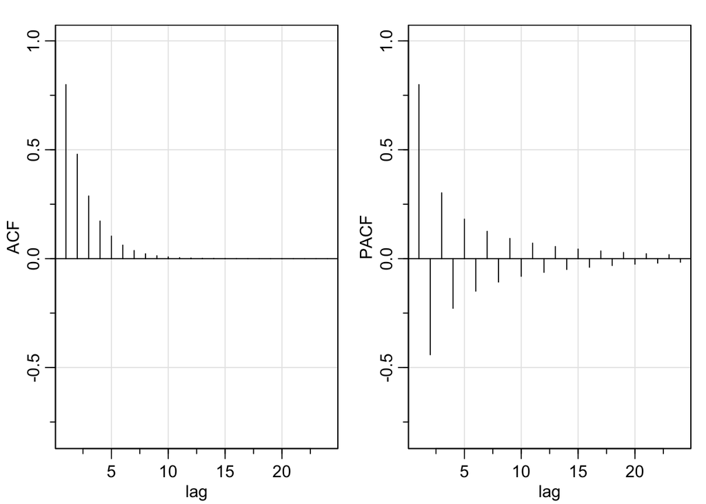

```r
ACF = ARMAacf(ar = c(0.6), ma = c(0.9), 24)[-1]
PACF = ARMAacf(ar = c(0.6), ma = c(0.9), 24, pacf = TRUE)
par(mfrow = 1:2)
tsplot(ACF, type = "h", xlab = "lag", ylim = c(-.8, 1))
abline(h = 0)
tsplot(PACF, type = "h", xlab = "lag", ylim = c(-.8, 1))
abline(h = 0)
```

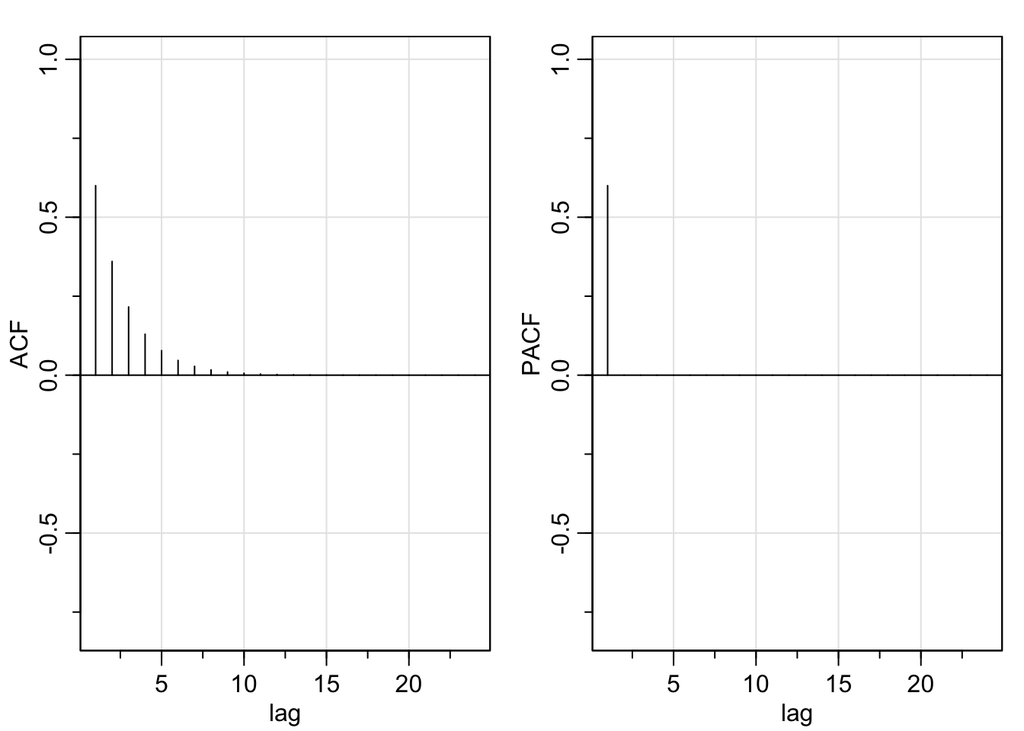

```r
ACF = ARMAacf(ar = c(0.6), ma = 0, 24)[-1]
PACF = ARMAacf(ar = c(0.6), ma = 0, 24, pacf = TRUE)
par(mfrow = 1:2)
tsplot(ACF, type = "h", xlab = "lag", ylim = c(-.8, 1))
abline(h = 0)
tsplot(PACF, type = "h", xlab = "lag", ylim = c(-.8, 1))
abline(h = 0)
```

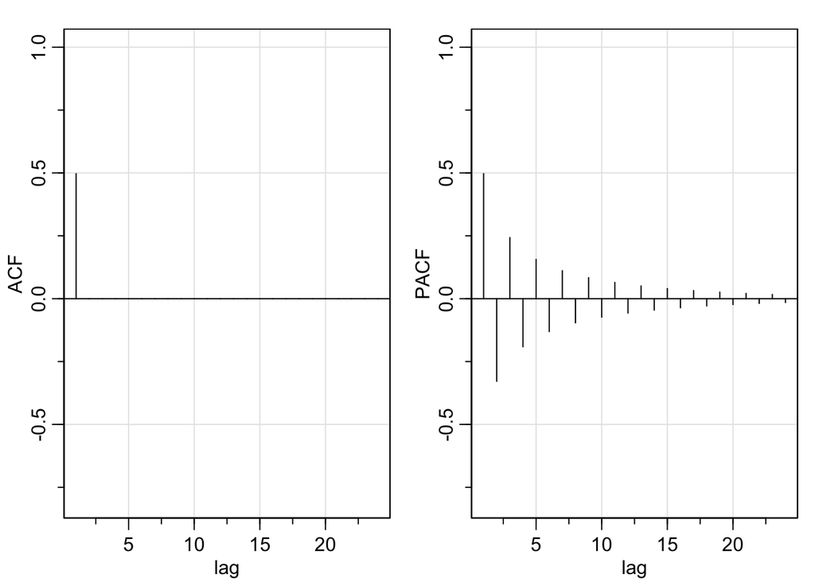

```r
ACF = ARMAacf(ar = 0, ma = c(0.9), 24)[- 1 ]
PACF = ARMAacf(ar = 0, ma = c(0.9), 24, pacf = TRUE)
par(mfrow = 1:2)
tsplot(ACF, type = "h", xlab = "lag", ylim = c(-.8, 1))
abline(h = 0)
tsplot(PACF, type = "h", xlab = "lag", ylim = c(-.8, 1))
abline(h = 0)
```

In ARMA(1,1) both acf & pacf tails off and it is little difficult to find the value of *p* and *q*. In ARMA(1,0) acf tails off and pacf cutf off after lag p (p=1 in this case) which gives us the insight that the model is AR(1). In ARMA(0,1) acf cuts off after lag q(q=1 in this case) and pacf tails off which gives us the insight that the model is MA(1).

### Part b)

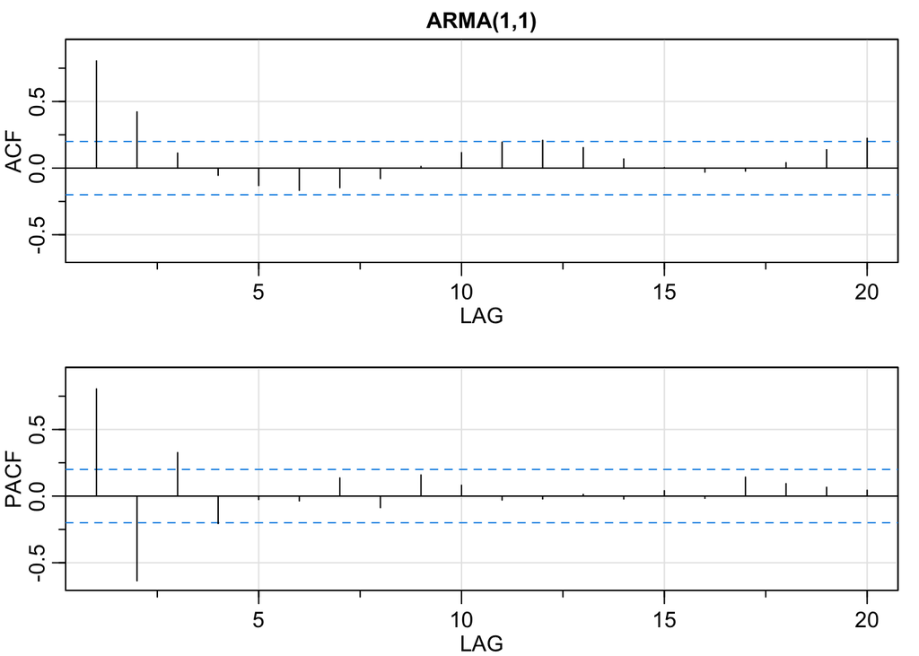

```
##      [,1]  [,2] [,3]  [,4]  [,5]  [,6]  [,7]  [,8] [,9] [,10] [,11] [,12] [,13]
## ACF   0.8  0.42 0.11 -0.05 -0.13 -0.17 -0.15 -0.08 0.01  0.12  0.19  0.21  0.15
## PACF  0.8 -0.64 0.33 -0.21 -0.03 -0.04  0.14 -0.09 0.16  0.08 -0.03 -0.02  0.01
##      [,14] [,15] [,16] [,17] [,18] [,19] [,20]
## ACF   0.07  0.00 -0.03 -0.02  0.04  0.14  0.22
## PACF -0.02  0.04 -0.02  0.14  0.09  0.07  0.04
```

```r
acf2(arima.sim(list(order=c(1,0,1), ar=.6, ma=.9), n=100),main = "ARMA(1,1)")
```

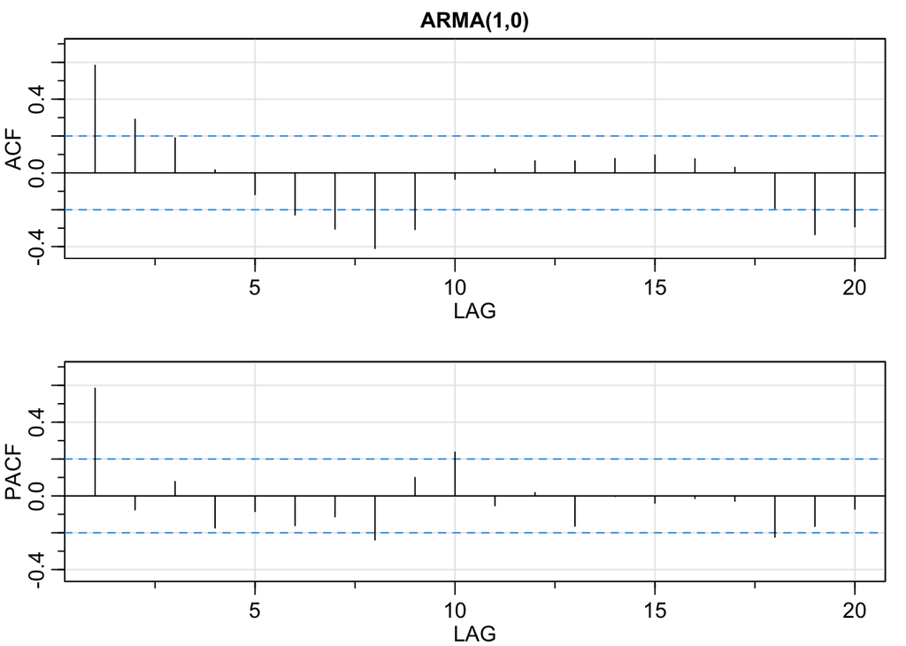

```
##      [,1]  [,2] [,3]  [,4]  [,5]  [,6]  [,7]  [,8]  [,9] [,10] [,11] [,12]
## ACF  0.58  0.29 0.19  0.02 -0.12 -0.23 -0.30 -0.41 -0.31 -0.03  0.02  0.07
## PACF 0.58 -0.08 0.08 -0.17 -0.08 -0.16 -0.11 -0.24  0.10  0.24 -0.05  0.02
##      [,13] [,14] [,15] [,16] [,17] [,18] [,19] [,20]
## ACF   0.07  0.08  0.10  0.08  0.03 -0.19 -0.33 -0.29
## PACF -0.16  0.00 -0.04 -0.01 -0.03 -0.22 -0.16 -0.07
```

```r
acf2(arima.sim(list(order=c(1,0,0), ar=.6), n=100),main = "ARMA(1,0)")
```

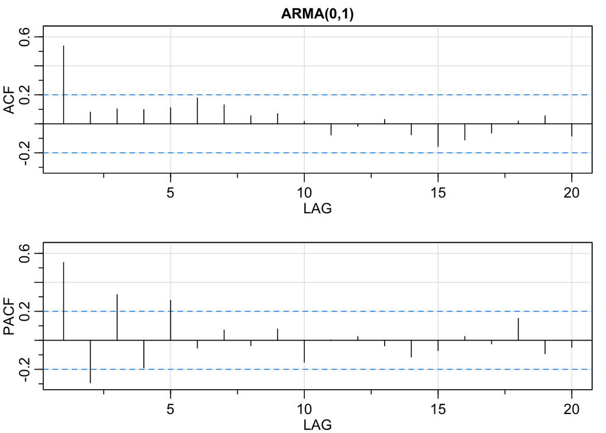

```
##      [,1]  [,2] [,3]  [,4] [,5]  [,6] [,7]  [,8] [,9] [,10] [,11] [,12] [,13]
## ACF  0.54  0.08 0.10  0.10 0.11  0.18 0.13  0.06 0.07  0.02 -0.08 -0.02  0.03
## PACF 0.54 -0.29 0.32 -0.19 0.28 -0.05 0.07 -0.04 0.08 -0.15  0.00  0.03 -0.04
##      [,14] [,15] [,16] [,17] [,18] [,19] [,20]
## ACF  -0.08 -0.16 -0.11 -0.06  0.02  0.05 -0.08
## PACF -0.11 -0.07  0.03 -0.02  0.15 -0.09 -0.05
```

```r
acf2(arima.sim(list(order=c(0,0,1), ma=.9), n=100),main = "ARMA(0,1)")
```

The practical values are close to the theoretical values but in practical values are negligible but not zero.

### Part c)

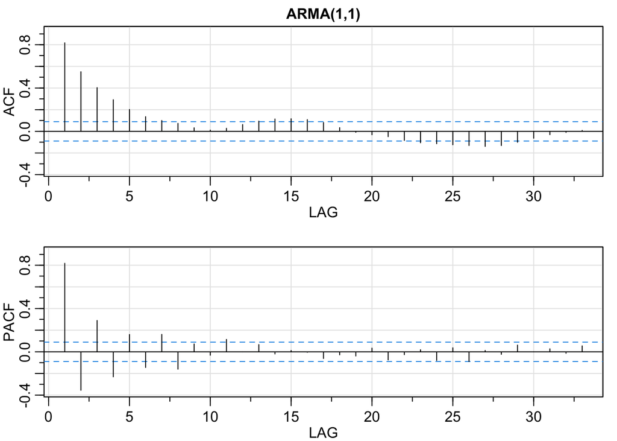

```
##      [,1]  [,2] [,3]  [,4] [,5]  [,6] [,7]  [,8] [,9] [,10] [,11] [,12] [,13]
## ACF  0.82  0.55 0.40  0.29 0.20  0.14 0.10  0.07 0.03  0.01  0.03  0.06  0.09
## PACF 0.82 -0.36 0.29 -0.23 0.16 -0.14 0.16 -0.16 0.07 -0.03  0.11  0.00  0.07
##      [,14] [,15] [,16] [,17] [,18] [,19] [,20] [,21] [,22] [,23] [,24] [,25]
## ACF   0.11  0.12  0.11  0.08  0.03 -0.01 -0.03 -0.05 -0.08 -0.11 -0.11 -0.12
## PACF -0.02  0.01  0.00 -0.06 -0.03 -0.04  0.03 -0.07 -0.03  0.02 -0.08  0.04
##      [,26] [,27] [,28] [,29] [,30] [,31] [,32] [,33]
## ACF  -0.13 -0.14 -0.13 -0.10 -0.06 -0.03 -0.01  0.01
## PACF -0.09  0.01 -0.02  0.06  0.00  0.03 -0.01  0.05
```

```r
acf2(arima.sim(list(order=c(1,0,1), ar=.6, ma=.9), n=500),main = "ARMA(1,1)")
```

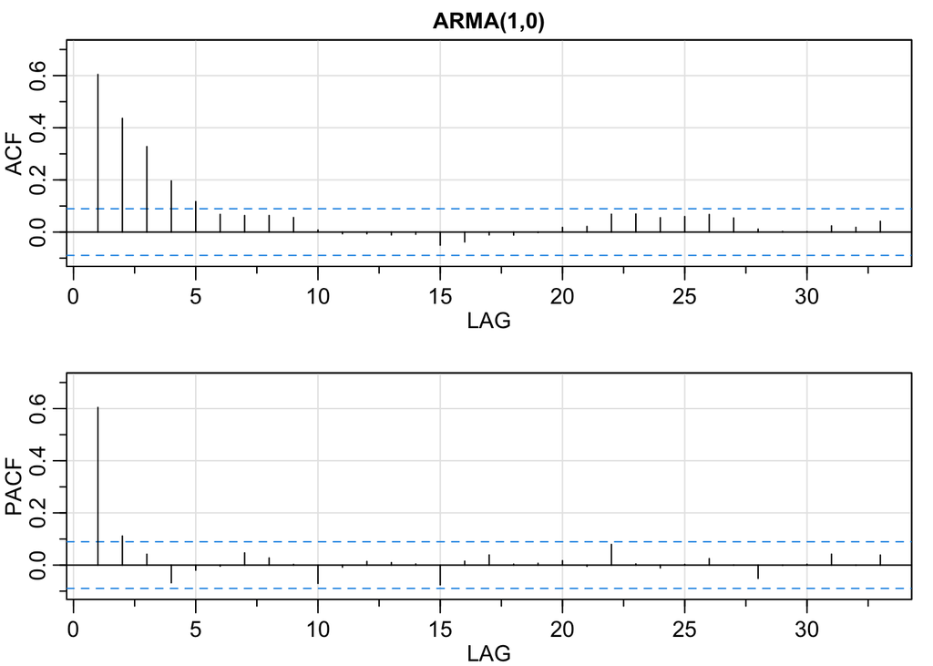

```
##      [,1] [,2] [,3]  [,4]  [,5] [,6] [,7] [,8] [,9] [,10] [,11] [,12] [,13]
## ACF   0.6 0.44 0.33  0.20  0.12 0.07 0.06 0.06 0.06  0.01 -0.01 -0.01 -0.01
## PACF  0.6 0.11 0.04 -0.07 -0.02 0.00 0.05 0.03 0.00 -0.07 -0.01  0.01  0.01
##      [,14] [,15] [,16] [,17] [,18] [,19] [,20] [,21] [,22] [,23] [,24] [,25]
## ACF  -0.01 -0.05 -0.04 -0.01 -0.01  0.00  0.02  0.02  0.07  0.07  0.06  0.06
## PACF  0.00 -0.08  0.01  0.04  0.00  0.01  0.02  0.00  0.08  0.00 -0.01  0.00
##      [,26] [,27] [,28] [,29] [,30] [,31] [,32] [,33]
## ACF   0.07  0.05  0.01     0     0  0.02  0.02  0.04
## PACF  0.02  0.00 -0.05     0     0  0.04  0.00  0.04
```

```r
acf2(arima.sim(list(order=c(1,0,0), ar=.6), n=500),main = "ARMA(1,0)")
```

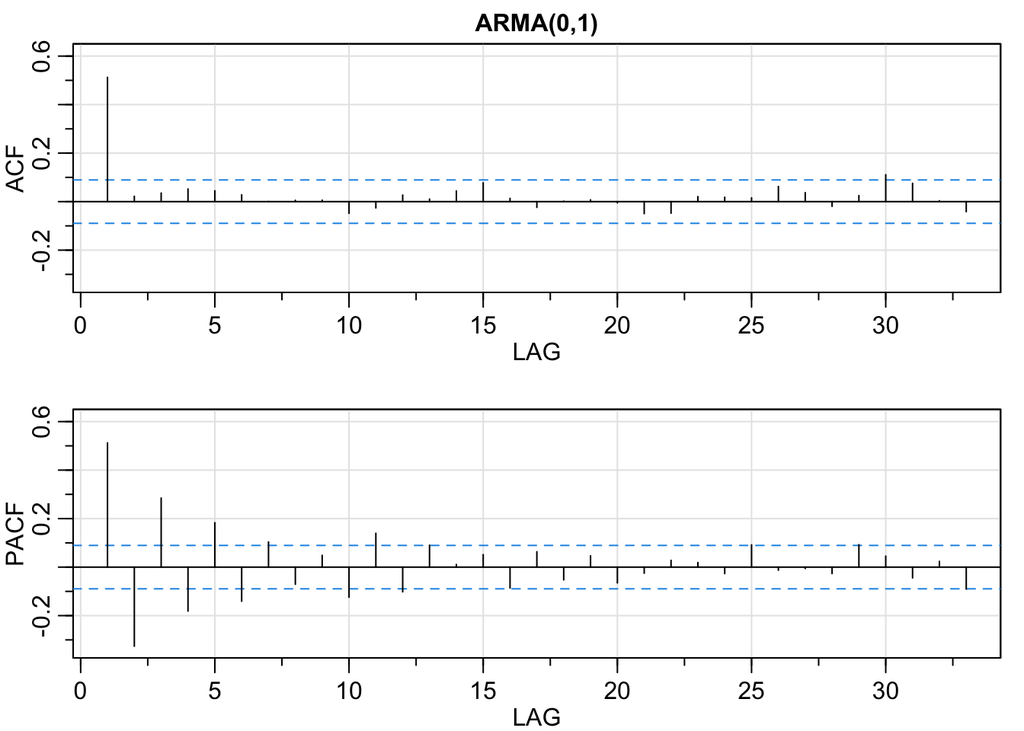

```
##      [,1]  [,2] [,3]  [,4] [,5]  [,6] [,7]  [,8] [,9] [,10] [,11] [,12] [,13]
## ACF  0.51  0.02 0.04  0.05 0.04  0.03  0.0  0.01 0.01 -0.05 -0.03  0.03  0.01
## PACF 0.51 -0.33 0.28 -0.18 0.18 -0.14  0.1 -0.07 0.05 -0.12  0.14 -0.10  0.09
##      [,14] [,15] [,16] [,17] [,18] [,19] [,20] [,21] [,22] [,23] [,24] [,25]
## ACF   0.04  0.08  0.01 -0.02  0.00  0.01 -0.01 -0.05 -0.05  0.02  0.02  0.02
## PACF  0.01  0.05 -0.09  0.06 -0.05  0.05 -0.07 -0.03  0.03  0.02 -0.03  0.09
##      [,26] [,27] [,28] [,29] [,30] [,31] [,32] [,33]
## ACF   0.06  0.04 -0.02  0.02  0.11  0.08  0.00 -0.04
## PACF -0.01 -0.01 -0.03  0.09  0.05 -0.04  0.02 -0.09
```

```r
acf2(arima.sim(list(order=c(0,0,1), ma=.9), n=500),main = "ARMA(0,1)")
```

As the number is higher, it more closely relates to theoretical values.

## Problem 4.5

### Part a)

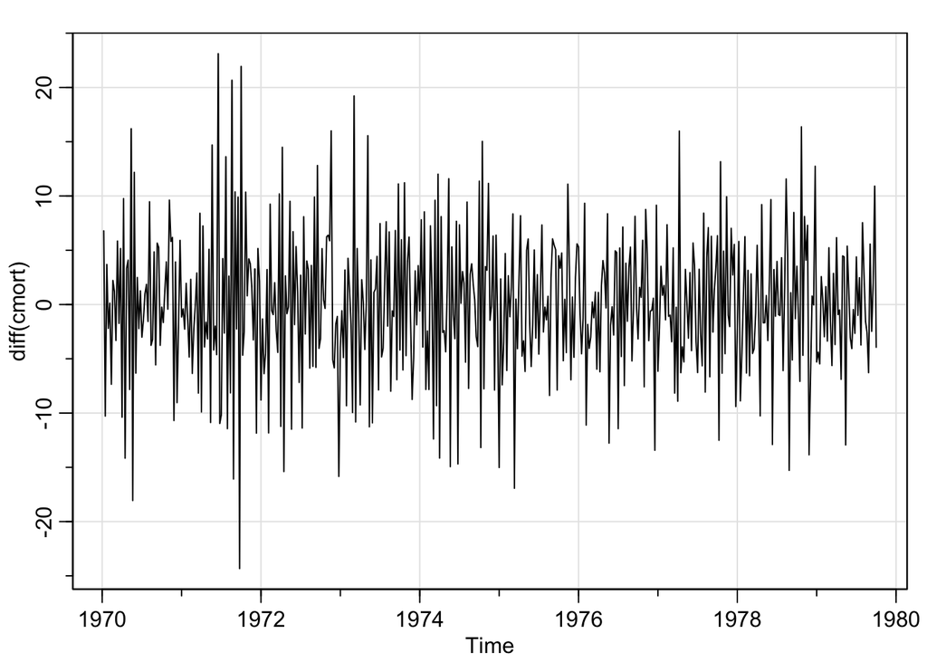

```r
tsplot(diff(cmort))
```

Differencing seems reasonable in this case as it produces fairly stationary time series and removes the trend from the data.

### Part b)

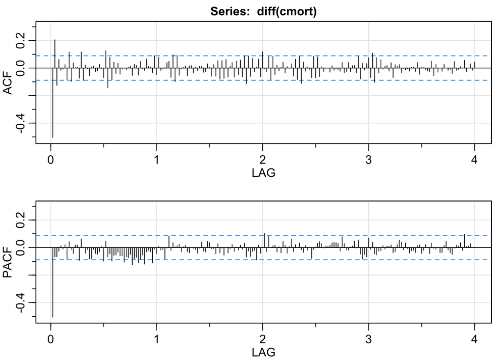

```
##       [,1]  [,2]  [,3]  [,4]  [,5]  [,6] [,7]  [,8] [,9] [,10] [,11] [,12]
## ACF  -0.51  0.21 -0.13  0.06 -0.02 -0.01 0.02 -0.09 0.12 -0.10  0.04  0.00
## PACF -0.51 -0.07 -0.07 -0.03  0.01 -0.01 0.02 -0.09 0.04 -0.01 -0.04  0.02
##      [,13] [,14] [,15] [,16] [,17] [,18] [,19] [,20] [,21] [,22] [,23] [,24]
## ACF   0.01 -0.07  0.12 -0.09  0.02 -0.01 -0.06  0.01  0.01 -0.03 -0.02  0.03
## PACF  0.02 -0.09  0.06  0.00 -0.04 -0.01 -0.08 -0.08 -0.01 -0.04 -0.05 -0.03
##      [,25] [,26] [,27] [,28] [,29] [,30] [,31] [,32] [,33] [,34] [,35] [,36]
## ACF  -0.01 -0.07  0.13 -0.14  0.08 -0.08  0.04 -0.04  0.03 -0.04 -0.01  0.00
## PACF  0.01 -0.10  0.05 -0.07 -0.04 -0.10 -0.06 -0.05 -0.03 -0.06 -0.06 -0.11
##      [,37] [,38] [,39] [,40] [,41] [,42] [,43] [,44] [,45] [,46] [,47] [,48]
## ACF  -0.01  0.00  0.01 -0.05  0.03  0.02 -0.05  0.05 -0.01 -0.02  0.06  0.01
## PACF -0.07 -0.07 -0.05 -0.13 -0.08 -0.07 -0.11 -0.09 -0.05 -0.12 -0.03 -0.02
##      [,49] [,50] [,51] [,52] [,53] [,54] [,55] [,56] [,57] [,58] [,59] [,60]
## ACF   0.00 -0.03  0.09 -0.05  0.08 -0.02 -0.01  0.00  0.04  0.05 -0.07  0.10
## PACF -0.03 -0.11 -0.01 -0.04  0.01 -0.02 -0.01 -0.08  0.00  0.08 -0.02  0.04
##      [,61] [,62] [,63] [,64] [,65] [,66] [,67] [,68] [,69] [,70] [,71] [,72]
## ACF  -0.10  0.09 -0.05 -0.01  0.00  0.01 -0.06  0.02  0.02 -0.03  0.01 -0.02
## PACF  0.01  0.01  0.02 -0.03  0.01  0.01 -0.03 -0.04  0.00 -0.01 -0.02 -0.04
##      [,73] [,74] [,75] [,76] [,77] [,78] [,79] [,80] [,81] [,82] [,83] [,84]
## ACF   0.01  0.01 -0.03 -0.03  0.03  0.00 -0.06  0.02 -0.06  0.05 -0.08  0.05
## PACF  0.00  0.04 -0.03 -0.03  0.04  0.04 -0.01 -0.01 -0.05  0.03 -0.04  0.00
##      [,85] [,86] [,87] [,88] [,89] [,90] [,91] [,92] [,93] [,94] [,95] [,96]
## ACF  -0.07  0.06 -0.07  0.01  0.04 -0.07  0.05 -0.05  0.06 -0.06  0.09 -0.11
## PACF -0.06  0.00 -0.04 -0.01  0.02 -0.03  0.00 -0.02  0.02 -0.01  0.03 -0.07
##      [,97] [,98] [,99] [,100] [,101] [,102] [,103] [,104] [,105] [,106] [,107]
## ACF   0.09 -0.06  0.07  -0.03   0.01   0.07  -0.06   0.12    0.0  -0.03   0.08
## PACF -0.03 -0.06 -0.03  -0.02  -0.09   0.02  -0.04   0.00    0.1  -0.03   0.08
##      [,108] [,109] [,110] [,111] [,112] [,113] [,114] [,115] [,116] [,117]
## ACF   -0.09   0.09  -0.05   0.02  -0.02   0.00   0.04  -0.04   0.01   0.00
## PACF   0.00   0.01   0.02  -0.03   0.01  -0.04   0.04   0.02  -0.04   0.01
##      [,118] [,119] [,120] [,121] [,122] [,123] [,124] [,125] [,126] [,127]
## ACF    0.03  -0.06   0.06  -0.08   0.09  -0.11   0.04  -0.02   0.01  -0.01
## PACF   0.06  -0.03   0.02   0.00   0.03  -0.02  -0.04   0.01  -0.02   0.00
##      [,128] [,129] [,130] [,131] [,132] [,133] [,134] [,135] [,136] [,137]
## ACF   -0.07   0.09  -0.07   0.08  -0.06   0.01  -0.03   0.00   0.00  -0.03
## PACF  -0.08  -0.01   0.00   0.03   0.04   0.03   0.00   0.01   0.01   0.02
##      [,138] [,139] [,140] [,141] [,142] [,143] [,144] [,145] [,146] [,147]
## ACF    0.02  -0.01   0.00  -0.01  -0.02   0.04  -0.04  -0.03   0.04  -0.02
## PACF   0.03   0.04   0.03   0.03  -0.03   0.08   0.03  -0.02  -0.02   0.00
##      [,148] [,149] [,150] [,151] [,152] [,153] [,154] [,155] [,156] [,157]
## ACF    0.02   0.02  -0.03   0.08  -0.08   0.03  -0.02   0.03   0.07  -0.07
## PACF   0.01   0.05   0.00   0.05  -0.05  -0.08  -0.05  -0.07   0.07  -0.01
##      [,158] [,159] [,160] [,161] [,162] [,163] [,164] [,165] [,166] [,167]
## ACF    0.11  -0.10   0.08  -0.03   0.06  -0.01   0.01   0.02  -0.02   0.04
## PACF   0.04  -0.05  -0.05  -0.03  -0.02   0.01  -0.01   0.01   0.01   0.02
##      [,168] [,169] [,170] [,171] [,172] [,173] [,174] [,175] [,176] [,177]
## ACF   -0.07   0.02   0.01   0.02  -0.03   0.00  -0.01  -0.01  -0.02   0.01
## PACF  -0.04  -0.03   0.02   0.05   0.04  -0.02   0.03  -0.01  -0.04  -0.02
##      [,178] [,179] [,180] [,181] [,182] [,183] [,184] [,185] [,186] [,187]
## ACF    0.01  -0.02   0.04  -0.04   0.00   0.00  -0.01  -0.02  -0.03   0.05
## PACF  -0.02  -0.04   0.01   0.02  -0.04  -0.02   0.02   0.00  -0.04   0.03
##      [,188] [,189] [,190] [,191] [,192] [,193] [,194] [,195] [,196] [,197]
## ACF   -0.06   0.03  -0.03   0.00  -0.02   0.03   0.00  -0.02  -0.01  -0.04
## PACF  -0.01  -0.01   0.00  -0.04  -0.04   0.01   0.04  -0.02  -0.04  -0.05
##      [,198] [,199] [,200] [,201] [,202] [,203] [,204] [,205] [,206] [,207]
## ACF    0.05  -0.02  -0.01   0.01   0.00   0.06  -0.03   0.00   0.03  -0.02
## PACF   0.00   0.02   0.01   0.03  -0.02   0.09   0.01   0.01   0.03   0.00
##      [,208]
## ACF    0.04
## PACF   0.00
```

```r
acf2(diff(cmort))
```

AR(1) is appropriate for $x_{t}$ because ACF is tailing off.PACF cuts off after lag = 1 and values are nearly closely to zero.

### Part c)

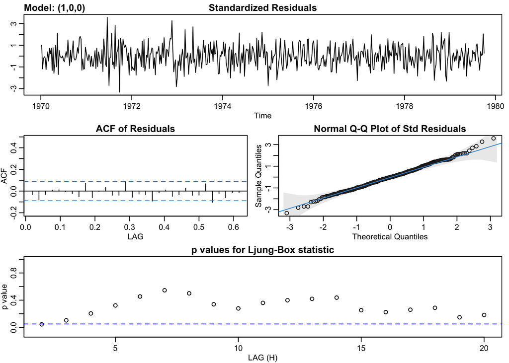

```
## $fit
##
## Call:
## stats::arima(x = xdata, order = c(p, d, q), seasonal = list(order = c(P, D,
##     Q), period = S), xreg = xmean, include.mean = FALSE, transform.pars = trans,
##     fixed = fixed, optim.control = list(trace = trc, REPORT = 1, reltol = tol))
##
## Coefficients:
##           ar1
##       -0.5064
## s.e.   0.0383
##
## sigma^2 estimated as 33.81:  log likelihood = -1612.07,  aic = 3228.13
##
## $degrees_of_freedom
## [1] 506
##
## $ttable
##     Estimate     SE  t.value p.value
## ar1  -0.5064 0.0383 -13.2224       0
##
## $AIC
## [1] 6.367124
##
## $AICc
## [1] 6.36714
##
## $BIC
## [1] 6.383805
```

```r
sarima(diff(cmort), p=1,d=0,q=0, no.constant = TRUE)
```

As the P value is zero, it proves the regression coefficients are significant.

### Part d)

```r
library(astsa)
value = sarima(diff(cmort), p=1,d=0,q=0, no.constant = TRUE)
```

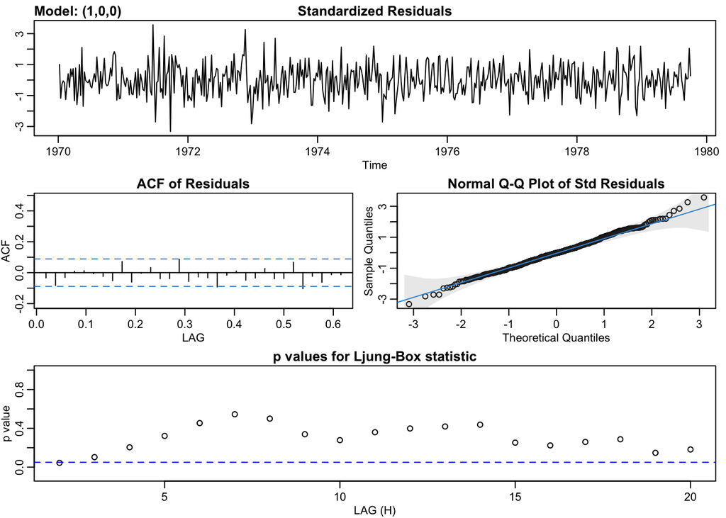

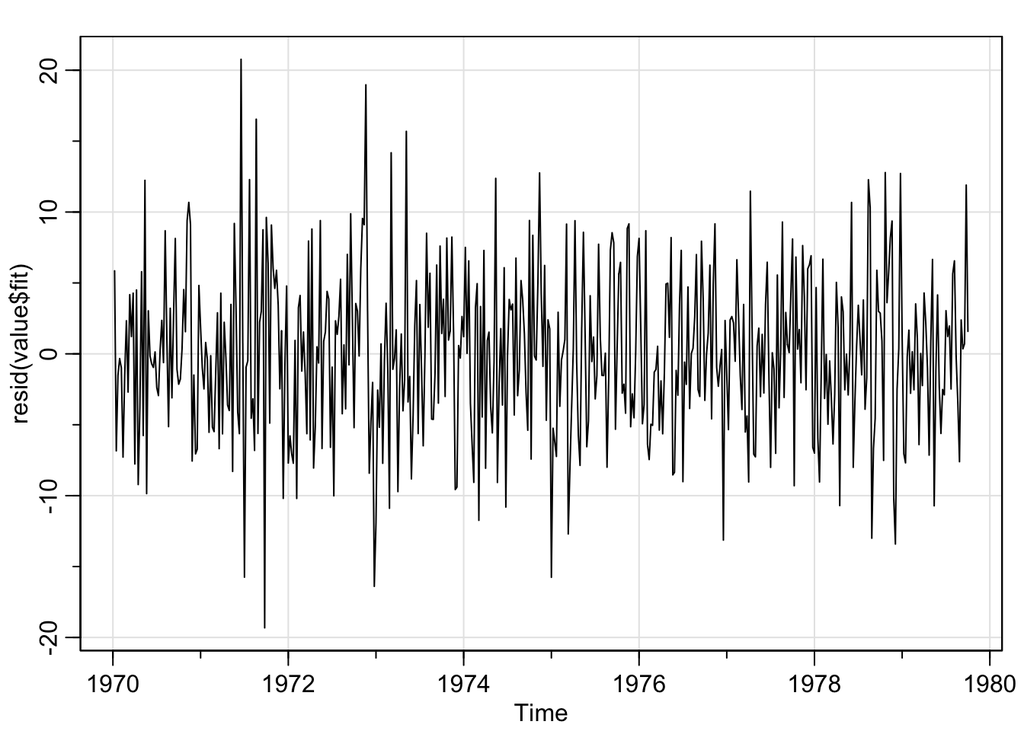

```r
tsplot(resid(value$fit))
```

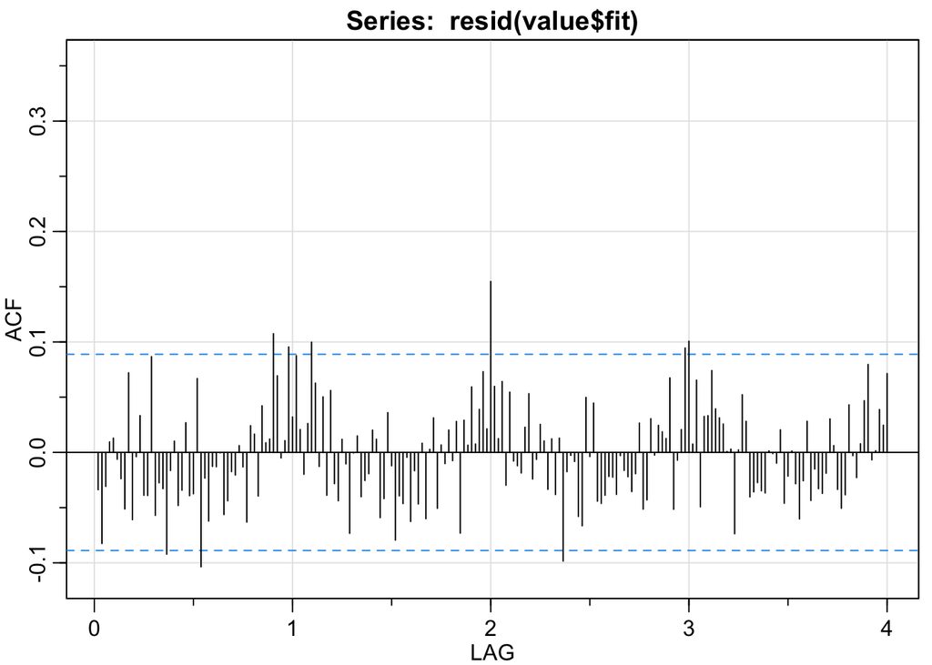

```
##   [1] -0.03 -0.08 -0.03  0.01  0.01 -0.01 -0.02 -0.05  0.07 -0.06  0.00  0.03
##  [13] -0.04 -0.04  0.09 -0.06 -0.03 -0.03 -0.09 -0.02  0.01 -0.05 -0.03  0.03
##  [25] -0.04 -0.04  0.07 -0.10 -0.02 -0.06 -0.01 -0.01  0.00 -0.06 -0.04 -0.02
##  [37] -0.02  0.01 -0.01 -0.06  0.02  0.02 -0.04  0.04  0.01  0.01  0.11  0.07
##  [49] -0.01  0.01  0.10  0.03  0.09  0.02 -0.02  0.03  0.10  0.06 -0.01  0.05
##  [61] -0.04  0.06 -0.03 -0.04  0.01 -0.01 -0.07  0.00  0.01 -0.04 -0.03 -0.02
##  [73]  0.02  0.01 -0.06 -0.04  0.04 -0.01 -0.08 -0.04 -0.05  0.00 -0.06 -0.02
##  [85] -0.05  0.01 -0.06  0.00  0.03 -0.05  0.01 -0.01  0.02 -0.01  0.03 -0.07
##  [97]  0.03  0.01  0.06  0.01  0.04  0.07  0.02  0.15  0.06  0.01  0.06 -0.03
## [109]  0.05 -0.01 -0.01 -0.02  0.02  0.05 -0.02 -0.01  0.03  0.01 -0.03  0.01
## [121] -0.04  0.01 -0.10 -0.02  0.00 -0.01 -0.06 -0.07  0.05  0.00  0.04 -0.04
## [133] -0.05 -0.04 -0.02 -0.02 -0.04  0.00 -0.02 -0.02 -0.04 -0.02  0.03 -0.05
## [145] -0.04  0.03  0.00  0.02  0.02  0.01  0.07 -0.05 -0.01  0.02  0.09  0.10
## [157]  0.01  0.07 -0.05  0.03  0.03  0.07  0.04  0.03  0.03  0.00  0.00 -0.07
## [169]  0.00  0.05  0.03 -0.04 -0.04 -0.03 -0.03 -0.04  0.00  0.00 -0.01  0.02
## [181] -0.05 -0.02  0.00 -0.03 -0.06 -0.03  0.03 -0.04 -0.02 -0.03 -0.04 -0.02
## [193]  0.03  0.01 -0.03 -0.05 -0.04  0.04  0.00 -0.02  0.01  0.05  0.08 -0.01
## [205]  0.00  0.04  0.02  0.07
```

```r
acf1(resid(value$fit))
```

### Part e)

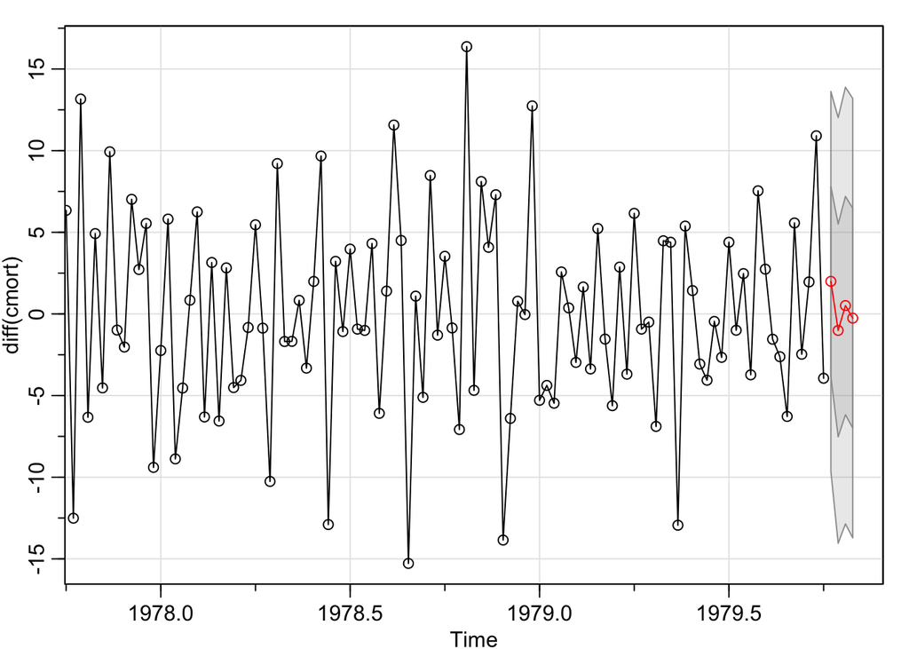

```r
forecastPlot <- sarima.for(diff(cmort), n.ahead=4,p=1,d=0,q=0,no.constant = TRUE)
```

The Predicted values

```r
forecastPlot$pred
```

```
## Time Series:
## Start = c(1979, 41)
## End = c(1979, 44)
## Frequency = 52
## [1]  1.9950506 -1.0102099  0.5115279 -0.2590162
```

The 95% interval values

```r
forecastPlot$pred + 1.96*forecastPlot$se
```

```
## Time Series:
## Start = c(1979, 41)
## End = c(1979, 44)
## Frequency = 52
## [1] 13.39183 11.76435 13.61604 12.92876
```

```r
forecastPlot$pred - 1.96*forecastPlot$se
```

```
## Time Series:
## Start = c(1979, 41)
## End = c(1979, 44)
## Frequency = 52
## [1]  -9.401733 -13.784772 -12.592983 -13.446796
```

### Part f)

The forecast is done based on the equation $x_{n+m}^n = \phi^{m} x_n + w_{n+m}$. Where the $\phi^m$ values are the PACF values of lag m at. So here if we want to forecast next value we are calculating $x_{n+1}^n = \phi x_n + w_{n+1}$.

As the $w_{n+1}$ is future error we equate it to zero $w_{n+1} = 0$. We can write the m - step ahead forecast as

$$x_{n+m}^n = \phi^m x_n$$
The last value of xt is

```r
xt = diff(cmort)
xt[length(xt)]
```

```
## [1] -3.94
```

From the above PACF plots from 4.5b the lag1 values are [-0.51] PACF at lag 1 is -0.51. So we can calculate our Next value which is
$$\begin{aligned}
x_{n+1} &= \phi x_{n}
\\
x_{n+1} &= (-0.51) * (-3.94)
\\
&= 2.0094
\end{aligned}$$
$$\begin{aligned}
x_{n+2} &= \phi^2 x_{n}
\\
x_{n+2} &= (-0.51)^2 * (-3.94)
\\
&= -1.024
\end{aligned}$$

$$\begin{aligned}
x_{n+3} &= \phi^3 x_{n}
\\
x_{n+3} &= (-0.51)^3 * (-3.94)
\\
&= 0.5226
\end{aligned}$$

$$\begin{aligned}
x_{n+4} &= \phi^4 x_{n}
\\
x_{n+4} &= (-0.51)^4 * (-3.94)
\\
&= -0.2665
\end{aligned}$$

### Part g)

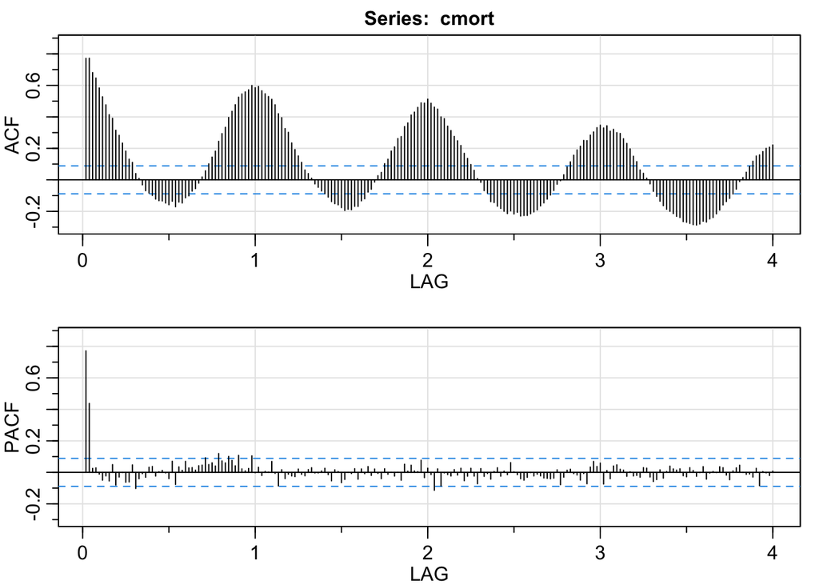

```
##      [,1] [,2] [,3] [,4]  [,5]  [,6]  [,7]  [,8] [,9] [,10] [,11] [,12] [,13]
## ACF  0.77 0.77 0.68 0.65  0.58  0.53  0.48  0.41 0.39  0.32  0.28  0.23  0.18
## PACF 0.77 0.44 0.03 0.03 -0.01 -0.05 -0.02 -0.05 0.05 -0.08 -0.03  0.00 -0.06
##      [,14] [,15] [,16] [,17] [,18] [,19] [,20] [,21] [,22] [,23] [,24] [,25]
## ACF   0.13  0.11  0.04  0.01 -0.03 -0.07 -0.08 -0.10 -0.12 -0.13 -0.13 -0.15
## PACF -0.06  0.05 -0.10 -0.04 -0.01 -0.03  0.03  0.04 -0.02  0.00  0.01  0.00
##      [,26] [,27] [,28] [,29] [,30] [,31] [,32] [,33] [,34] [,35] [,36] [,37]
## ACF  -0.16 -0.14 -0.17 -0.14 -0.15 -0.11 -0.10 -0.07 -0.06 -0.02  0.02  0.06
## PACF -0.04  0.07 -0.08  0.03  0.01  0.07  0.03  0.03  0.01  0.04  0.05  0.09
##      [,38] [,39] [,40] [,41] [,42] [,43] [,44] [,45] [,46] [,47] [,48] [,49]
## ACF   0.10  0.14  0.18  0.24  0.29  0.33   0.4  0.44  0.48  0.53  0.55  0.56
## PACF  0.05  0.06  0.04  0.12  0.07  0.06   0.1  0.08  0.04  0.11  0.02  0.01
##      [,50] [,51] [,52] [,53] [,54] [,55] [,56] [,57] [,58] [,59] [,60] [,61]
## ACF   0.57   0.6  0.58  0.59  0.57  0.55  0.53  0.51  0.48  0.42  0.39  0.33
## PACF  0.02   0.1  0.00  0.03 -0.02  0.01  0.00  0.07 -0.01 -0.09  0.02 -0.04
##      [,62] [,63] [,64] [,65] [,66] [,67] [,68] [,69] [,70] [,71] [,72] [,73]
## ACF   0.30  0.23  0.19  0.15  0.11  0.06  0.04  0.01 -0.03 -0.05 -0.07 -0.09
## PACF -0.01 -0.02 -0.03  0.02 -0.01 -0.02  0.02  0.03  0.00  0.00  0.01  0.03
##      [,74] [,75] [,76] [,77] [,78] [,79] [,80] [,81] [,82] [,83] [,84] [,85]
## ACF  -0.11 -0.14 -0.15 -0.16 -0.18 -0.19 -0.19 -0.19 -0.17 -0.17 -0.13 -0.12
## PACF -0.01 -0.05  0.02  0.00 -0.07 -0.04  0.00 -0.01  0.02 -0.04  0.02 -0.01
##      [,86] [,87] [,88] [,89] [,90] [,91] [,92] [,93] [,94] [,95] [,96] [,97]
## ACF  -0.08 -0.06 -0.01  0.03  0.05  0.10  0.13  0.18  0.21  0.26  0.28  0.34
## PACF  0.04 -0.02  0.02 -0.01 -0.04  0.02 -0.01  0.00 -0.02  0.00 -0.05  0.05
##      [,98] [,99] [,100] [,101] [,102] [,103] [,104] [,105] [,106] [,107] [,108]
## ACF   0.36  0.41   0.43   0.46   0.49   0.49   0.51   0.49   0.46   0.45   0.40
## PACF  0.01  0.05   0.01   0.00   0.08  -0.03   0.03  -0.01  -0.11   0.02  -0.09
##      [,109] [,110] [,111] [,112] [,113] [,114] [,115] [,116] [,117] [,118]
## ACF    0.39   0.34   0.31   0.28   0.25   0.22   0.17   0.14   0.10   0.06
## PACF   0.00  -0.01  -0.02   0.02  -0.02   0.03  -0.05  -0.02   0.03  -0.02
##      [,119] [,120] [,121] [,122] [,123] [,124] [,125] [,126] [,127] [,128]
## ACF    0.01  -0.02  -0.07  -0.08  -0.14  -0.14  -0.17  -0.18  -0.20  -0.21
## PACF  -0.07   0.02  -0.03  -0.01  -0.04   0.01   0.03  -0.02   0.01  -0.01
##      [,129] [,130] [,131] [,132] [,133] [,134] [,135] [,136] [,137] [,138]
## ACF   -0.20  -0.22  -0.21  -0.23  -0.23  -0.23  -0.22  -0.20  -0.19  -0.17
## PACF   0.06   0.00  -0.01  -0.04  -0.05  -0.03   0.00  -0.02  -0.01  -0.02
##      [,139] [,140] [,141] [,142] [,143] [,144] [,145] [,146] [,147] [,148]
## ACF   -0.15  -0.12  -0.10  -0.07  -0.03  -0.01   0.03   0.08   0.11   0.16
## PACF  -0.04  -0.04  -0.04  -0.04   0.02  -0.08  -0.03   0.01   0.02  -0.01
##      [,149] [,150] [,151] [,152] [,153] [,154] [,155] [,156] [,157] [,158]
## ACF    0.19   0.21   0.25   0.25   0.28   0.30   0.33   0.35   0.33   0.34
## PACF  -0.02  -0.05  -0.01  -0.07   0.03   0.07   0.04   0.06  -0.07   0.01
##      [,159] [,160] [,161] [,162] [,163] [,164] [,165] [,166] [,167] [,168]
## ACF    0.31   0.32   0.30   0.29   0.26   0.23    0.2   0.15   0.12   0.06
## PACF  -0.04   0.04   0.05   0.02   0.01  -0.03    0.0  -0.02  -0.02  -0.03
##      [,169] [,170] [,171] [,172] [,173] [,174] [,175] [,176] [,177] [,178]
## ACF    0.04   0.01  -0.03  -0.07  -0.10  -0.14  -0.16  -0.19  -0.20  -0.21
## PACF   0.03   0.03  -0.03  -0.06  -0.05   0.02  -0.04   0.01   0.04   0.02
##      [,179] [,180] [,181] [,182] [,183] [,184] [,185] [,186] [,187] [,188]
## ACF   -0.23  -0.24  -0.27  -0.27  -0.28  -0.28  -0.29  -0.28  -0.26  -0.27
## PACF   0.01   0.02  -0.02  -0.03   0.03   0.01  -0.03   0.00   0.04  -0.04
##      [,189] [,190] [,191] [,192] [,193] [,194] [,195] [,196] [,197] [,198]
## ACF   -0.25  -0.24  -0.22  -0.19  -0.16  -0.14  -0.12  -0.09  -0.06  -0.01
## PACF   0.00   0.01   0.00   0.04   0.03  -0.02  -0.05   0.01   0.03   0.05
##      [,199] [,200] [,201] [,202] [,203] [,204] [,205] [,206] [,207] [,208]
## ACF    0.01   0.05   0.09   0.12   0.15   0.16   0.18    0.2   0.21   0.22
## PACF   0.00  -0.01  -0.01  -0.03   0.03  -0.08   0.00    0.0  -0.02   0.01
```

```r
acf2(cmort)
```

After seeing the acf2 plot we can easily see that pacf cuts at lag=2 which means ARMA(2,0) would be a better model for the data.

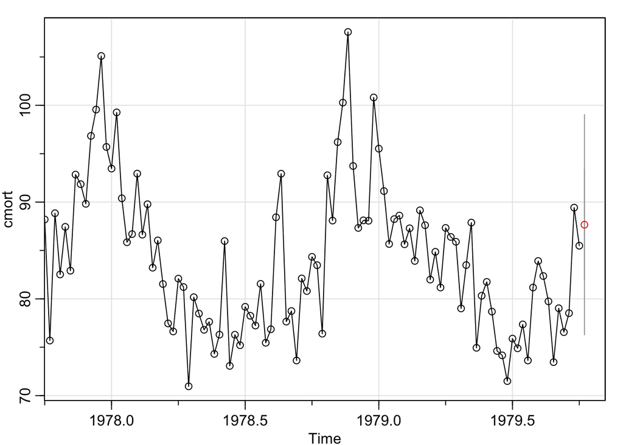

```
## $pred
## Time Series:
## Start = c(1979, 41)
## End = c(1979, 41)
## Frequency = 52
## [1] 87.66207
##
## $se
## Time Series:
## Start = c(1979, 41)
## End = c(1979, 41)
## Frequency = 52
## [1] 5.689543
```

```r
sarima.for(cmort, n.ahead=1,p=2,d=0,q=0)
```